# Untitled

Zhiming Guo

May 23, 2016

Load required libraries

```r
# Data wrangling
library(lubridate)
library(dplyr)

# For plotting
library(ggplot2)

# For regression tree
# library(MASS)
library(tree)

# For bagging and random forest models
library(randomForest)

### For the boosting model
library(gbm)


### For tuning models
library(caret)


### Fo xgboost model
library(xgboost)
```

Load and clean up data:

```r
load("data-raw/ListOfAllHeatwaves.Rdata")
fix_colnames <- which(colnames(all.hws) == "mean.temp")
colnames(all.hws)[fix_colnames[2]] <- "mean.temp.1"

hw <- all.hws %>%
  mutate(start.year = year(start.date))
colnames(hw) <- gsub(" ", ".", colnames(hw))
```

Create dataframes for fitting models for y1 and y2:

```r
hw <- hw %>%
  select(-hw.number, -start.date, -end.date, -id, -Std..Error,
         -city, -Posterior.Estimate, -Posterior.SE, -post.se)

to_fit_y1 <- hw %>%
  select(-post.estimate)

to_fit_y2 <- hw %>%
  select(-Estimate)

# Create a random subset of heat waves to use to train models
set.seed(1001) ##generate fixed random numbers
hw_indices <- 1:nrow(hw)

train <- sort(sample(hw_indices, length(hw_indices) / 2))
head(train)
```

```
## [1]  2  3  5  6  9 11
```

```r
test <- hw_indices[-train]
head(test)
```

```
## [1]  1  4  7  8 10 12
```

Fit a regression tree for $Y_1$:

```r
tree.hw <- tree(Estimate ~ ., data = to_fit_y1, subset = train)
summary(tree.hw)
```

```
##
## Regression tree:
## tree(formula = Estimate ~ ., data = to_fit_y1, subset = train)
## Variables actually used in tree construction:
## [1] "start.doy"         "min.temp.quantile" "Ppoverty"
## Number of terminal nodes:  4
## Residual mean deviance:  0.03799 = 56.46 / 1486
## Distribution of residuals:
##     Min.  1st Qu.   Median     Mean  3rd Qu.     Max.
## -2.37800 -0.09941  0.01519  0.00000  0.11770  0.85470
```

The variables included in this model are: start.doy, min.temp.quantile, Ppoverty. Here is a plot of the final tree for this model:

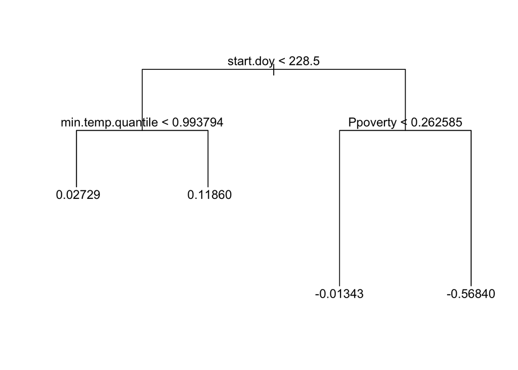

```r
plot(tree.hw)
text(tree.hw, pretty = 0)
```

Here are the results of using cross-validation to decide whether (and how much) to prune the tree:

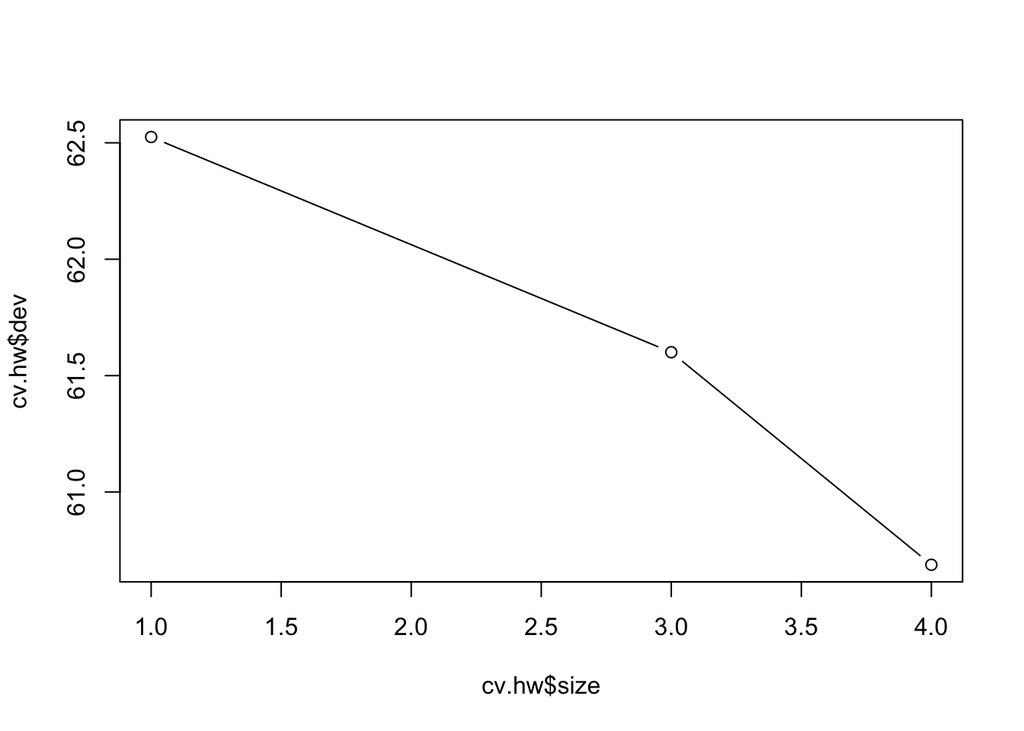

```r
cv.hw <- cv.tree(tree.hw)
plot(cv.hw$size, cv.hw$dev, type='b')
```

Based on this analysis, the best tree size would be 4 nodes.

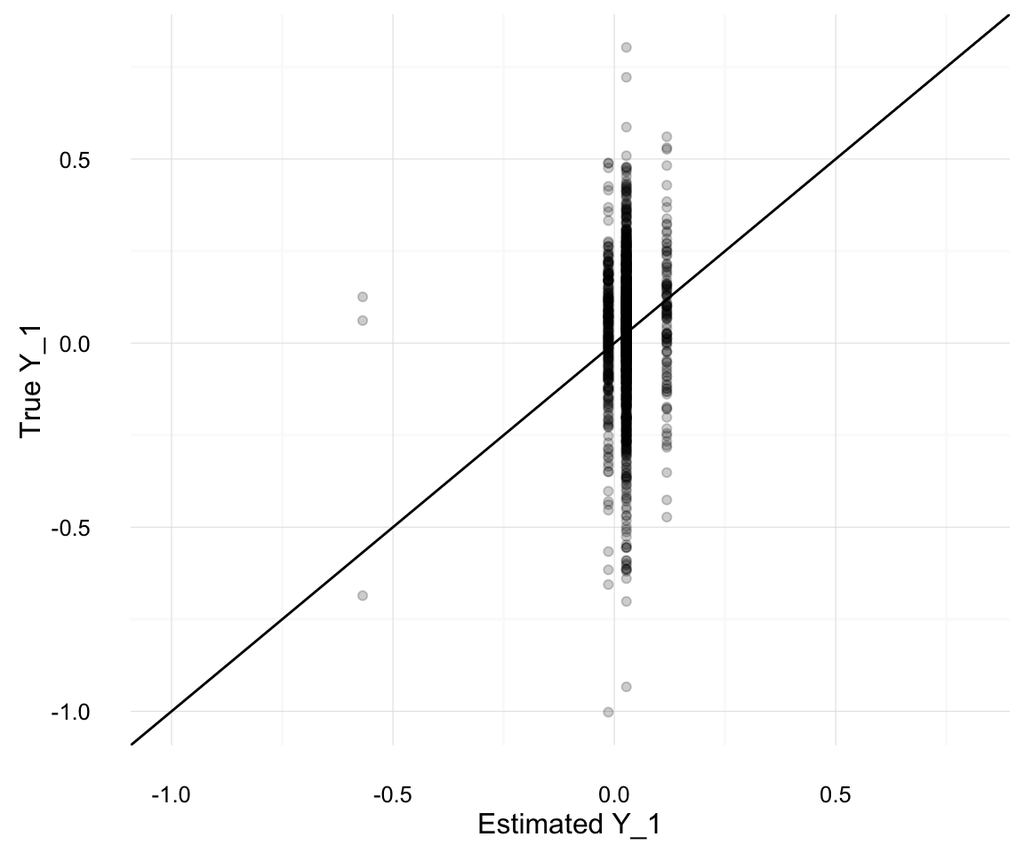

```r
yhat <- predict(tree.hw, newdata = to_fit_y1[test, ])

to_plot <- data.frame(estimated_y1 = yhat,
                      true_y1 = to_fit_y1[test, "Estimate"])
ggplot(to_plot, aes(x = estimated_y1, y = true_y1)) +
  geom_point(alpha = 0.2) +
  xlim(range(to_plot)) + ylim(range(to_plot)) +
  theme_minimal() +
  geom_abline(intercept = 0, slope = 1) +
  xlab("Estimated Y_1") + ylab("True Y_1")
```

The mean squared error for this model was 0.0363327.

Fit a bagging model:

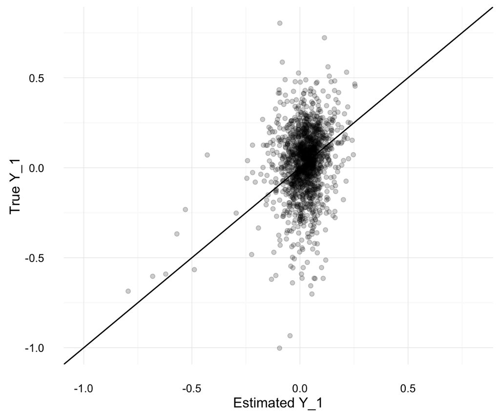

```r
set.seed(1)
bag.hw <- randomForest(Estimate ~ .,
                       data = to_fit_y1, subset = train,
                       mtry = ncol(to_fit_y1) - 1, importance = TRUE)

yhat.bag <- predict(bag.hw, newdata = to_fit_y1[test, ])

to_plot <- data.frame(estimated_y1 = yhat.bag,
                      true_y1 = to_fit_y1[test, "Estimate"])
ggplot(to_plot, aes(x = estimated_y1, y = true_y1)) +
  geom_point(alpha = 0.2) +
  xlim(range(to_plot)) + ylim(range(to_plot)) +
  theme_minimal() +
  geom_abline(intercept = 0, slope = 1) +
  xlab("Estimated Y_1") + ylab("True Y_1")
```

The mean squared error for this model was 4.533258410^{-5}.

Here is more on the variable importance for this model:

```r
importance(bag.hw)
```

```
##                      %IncMSE IncNodePurity
## mean.temp           7.127092    2.43573258
## max.temp           12.435896    1.93576641
## min.temp           10.426944    1.48729252
## length              6.082851    0.98018861
## start.doy           8.867151    8.44876104
## start.month         5.545108    0.53208653
## days.above.80       6.241774    0.64997029
## days.above.85       6.531809    0.29048742
## days.above.90       5.105985    0.21477811
## days.above.95       2.112760    0.03599527
## days.above.99th     2.167899    0.52560419
## days.above.99.5th   2.985387    0.29941594
## first.in.season     2.306548    0.72265838
## mean.temp.quantile  2.742567    3.99990699
## max.temp.quantile   2.970850    4.50393698
## min.temp.quantile   5.930149    4.25589726
## pop100              8.545890    3.04306541
## Ppoverty            8.651908    3.97522202
## Ppoverty75p         6.833760    2.09244802
## Purban              9.665649    1.51728436
## P75p               10.044029    1.88331991
## pop.density         9.685492    1.61661642
## mean.temp.1         7.041676    1.70637697
## mean.summer.temp   10.088439    1.43119714
## start.year         10.234676    7.86766924
```

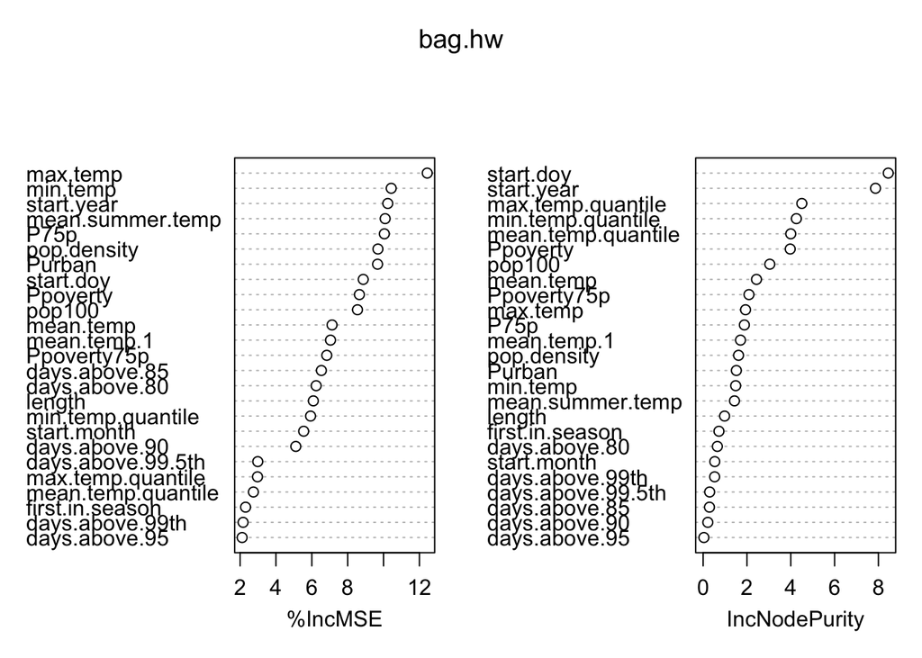

```r
varImpPlot(bag.hw)
```

Fitting a random forest model, with tuning:

```r
# Use 10-fold cross validation for tuning to find the best `mtry`
fitControl <- trainControl(method = "cv", number = 10)

set.seed(1)
tuning.rf.hw <- train(Estimate ~ ., data = to_fit_y1, subset = train,
                   method = "rf", trControl = fitControl, ntree = 10,
                   importance = TRUE, metric="RMSE",
                   maximize = FALSE, tuneLength=5)
```

Here are the results from that tuning process:

```r
tuning.rf.hw
```

```
## Random Forest
##
## 2980 samples
##   25 predictor
##
## No pre-processing
## Resampling: Cross-Validated (10 fold)
## Summary of sample sizes: 1342, 1341, 1339, 1339, 1342, 1342, ...
## Resampling results across tuning parameters:
##
##   mtry  RMSE       Rsquared
##    2    0.2041435  0.02051843
##    7    0.2081761  0.02619107
##   13    0.2025300  0.05091675
##   19    0.2022381  0.05765925
##   25    0.2036988  0.04836574
##
## RMSE was used to select the optimal model using  the smallest value.
## The final value used for the model was mtry = 19.
```

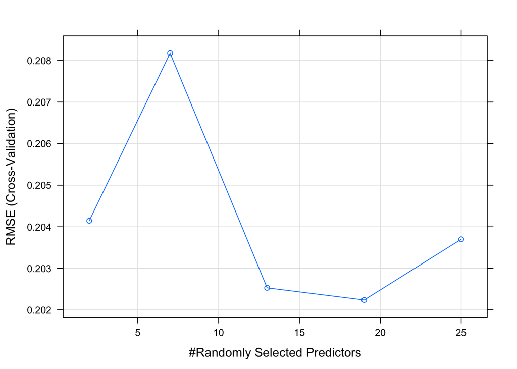

```r
plot(tuning.rf.hw)
```

Based on this tuning, the best value for `mtry` in the random forest model for this outcome is 19.

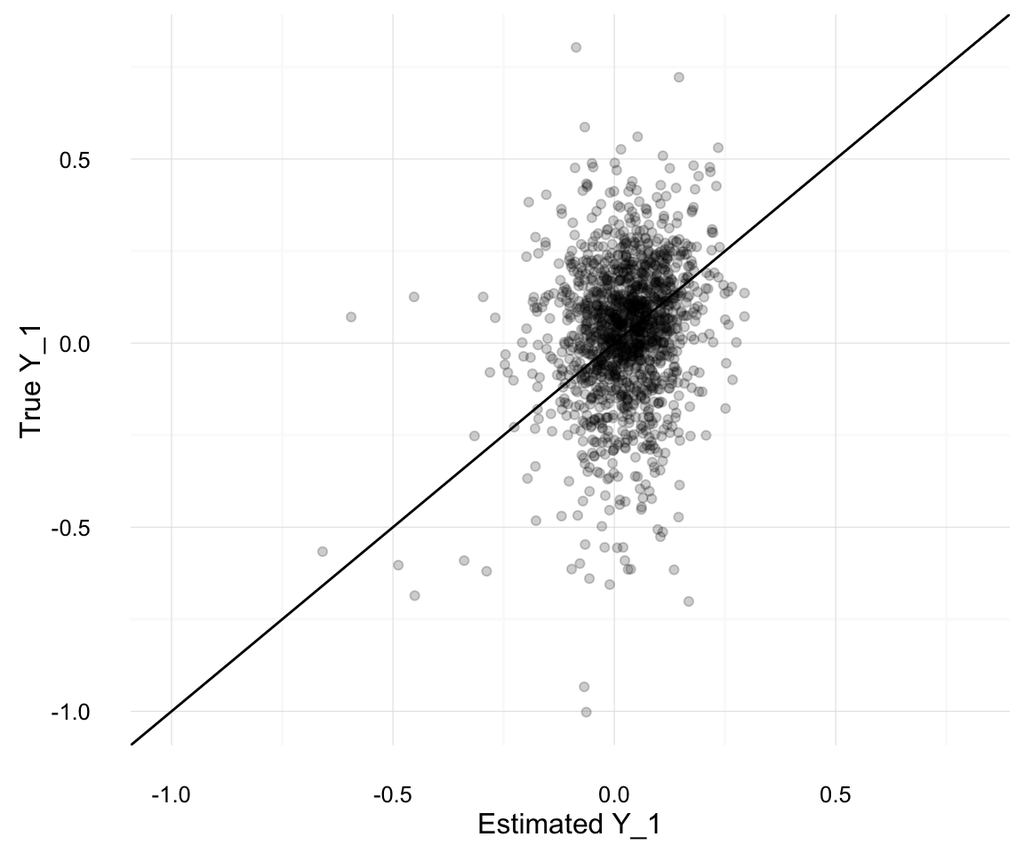

```r
yhat.rf <- predict(tuning.rf.hw$finalModel, newdata = to_fit_y1[test, ])

to_plot <- data.frame(estimated_y1 = yhat.rf,
                      true_y1 = to_fit_y1[test, "Estimate"])
ggplot(to_plot, aes(x = estimated_y1, y = true_y1)) +
  geom_point(alpha = 0.2) +
  xlim(range(to_plot)) + ylim(range(to_plot)) +
  theme_minimal() +
  geom_abline(intercept = 0, slope = 1) +
  xlab("Estimated Y_1") + ylab("True Y_1")
```

The mean squared error for this model was 1.093186510^{-5}.

Here are the variable importance plots:

```r
importance(tuning.rf.hw$finalModel)
```

```
##                        %IncMSE IncNodePurity
## mean.temp           2.09145601   2.201291869
## max.temp            1.59144388   1.957183048
## min.temp            3.17867200   1.495273519
## length              1.38093988   1.646819207
## start.doy           1.50580173   6.749238062
## start.month         1.36149982   0.800102981
## days.above.80       1.99678188   0.934009110
## days.above.85       1.31846692   0.281415382
## days.above.90       1.68037566   0.284349229
## days.above.95      -1.05409255   0.000438401
## days.above.99th     1.46687174   0.617808370
## days.above.99.5th   2.03173084   0.443275791
## first.in.season    -1.06282656   0.697164009
## mean.temp.quantile  1.99793943   4.278970715
## max.temp.quantile   2.38871728   4.321199142
## min.temp.quantile   3.10884927   3.762528078
## pop100              1.24118549   3.856162140
## Ppoverty           -1.09203395   4.870776390
## Ppoverty75p         0.36232123   1.527727356
## Purban             -0.85326202   1.498955910
## P75p                2.33854251   1.996748391
## pop.density        -0.05911208   2.259959535
## mean.temp.1         3.07875722   1.907943862
## mean.summer.temp    1.75185187   2.953429050
## start.year         -0.64510490   4.932279441
```

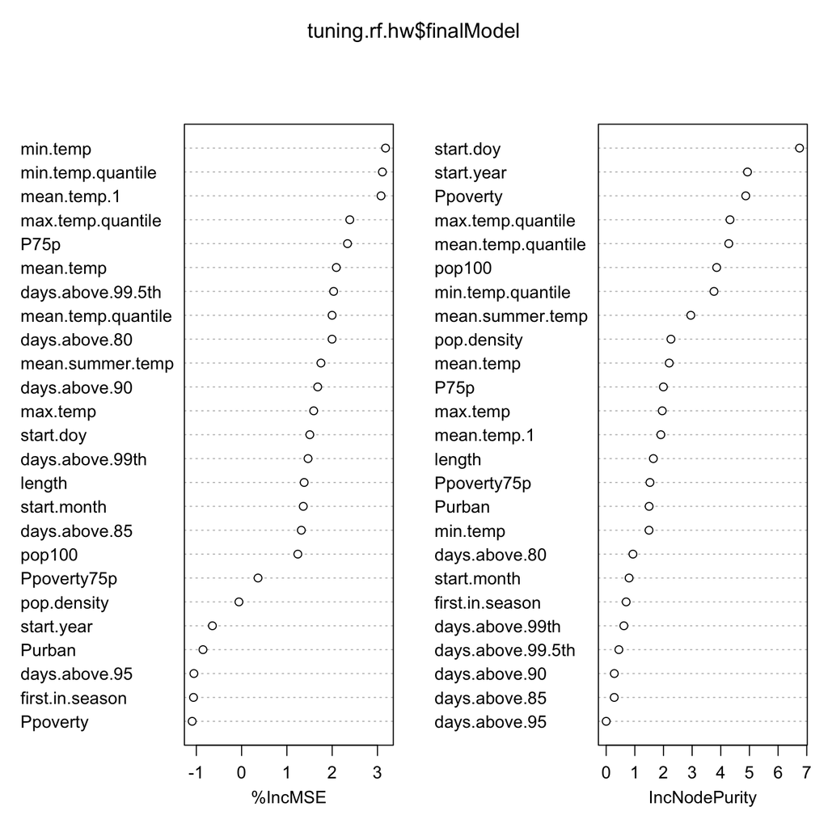

```r
varImpPlot(tuning.rf.hw$finalModel)
```

Fit a boosting model, with tuning

```r
#### Tuning to find best mtry for Boosting
gbmgrid <- expand.grid(.interaction.depth = seq(1, 7, by = 2),
                    .n.trees = seq(200, 300, by = 50),
                    .shrinkage = 0.01,
                    .n.minobsinnode = 10)
set.seed(1)


tuning.boost.hw <- train(Estimate~., data=to_fit_y1, subset = train,
                      method = "gbm",
                      tuneGrid = gbmgrid,
                      trControl = fitControl,
                      verbose = FALSE)
```

Here are the results from that tuning process:

```r
tuning.boost.hw
```

```
## Stochastic Gradient Boosting
##
## 2980 samples
##   25 predictor
##
## No pre-processing
## Resampling: Cross-Validated (10 fold)
## Summary of sample sizes: 1342, 1341, 1339, 1339, 1342, 1342, ...
## Resampling results across tuning parameters:
##
##   interaction.depth  n.trees  RMSE       Rsquared
##   1                  200      0.1963602  0.02355412
##   1                  250      0.1961963  0.02514483
##   1                  300      0.1960737  0.02539928
##   3                  200      0.1943382  0.04886052
##   3                  250      0.1940690  0.04990303
##   3                  300      0.1939298  0.04973778
##   5                  200      0.1935589  0.05298037
##   5                  250      0.1934279  0.05382856
##   5                  300      0.1934164  0.05450751
##   7                  200      0.1932483  0.05431748
##   7                  250      0.1928927  0.05916516
##   7                  300      0.1927448  0.06108164
##
## Tuning parameter 'shrinkage' was held constant at a value of 0.01
##
## Tuning parameter 'n.minobsinnode' was held constant at a value of 10
## RMSE was used to select the optimal model using  the smallest value.
## The final values used for the model were n.trees = 300,
##  interaction.depth = 7, shrinkage = 0.01 and n.minobsinnode = 10.
```

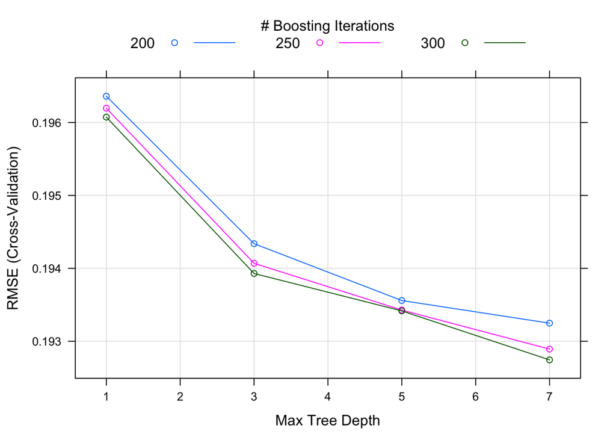

```r
plot(tuning.boost.hw)
```

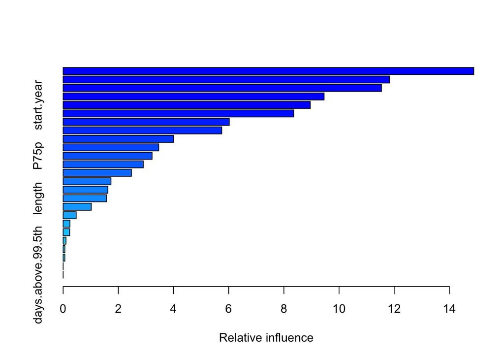

```
##                                   var     rel.inf
## start.doy                   start.doy 14.88277419
## Ppoverty                     Ppoverty 11.82899450
## min.temp.quantile   min.temp.quantile 11.53908846
## max.temp.quantile   max.temp.quantile  9.45913636
## start.year                 start.year  8.95745642
## pop100                         pop100  8.35650681
## mean.summer.temp     mean.summer.temp  6.02332101
## mean.temp.quantile mean.temp.quantile  5.74827696
## mean.temp.1               mean.temp.1  4.00569327
## Ppoverty75p               Ppoverty75p  3.46493136
## P75p                             P75p  3.22372214
## pop.density               pop.density  2.90401457
## Purban                         Purban  2.47631085
## max.temp                     max.temp  1.73398919
## mean.temp                   mean.temp  1.62002248
## length                         length  1.57204119
## min.temp                     min.temp  1.02055799
## days.above.80           days.above.80  0.47415939
## start.month               start.month  0.24548450
## first.in.season       first.in.season  0.23625402
## days.above.99th       days.above.99th  0.10341761
## days.above.85           days.above.85  0.06261714
## days.above.90           days.above.90  0.06122960
## days.above.95           days.above.95  0.00000000
## days.above.99.5th   days.above.99.5th  0.00000000
```

```r
boost.hw <- gbm(Estimate~., data = to_fit_y1[train,],
                distribution = "gaussian",
                n.trees = tuning.boost.hw$bestTune[,1],
                interaction.depth = tuning.boost.hw$bestTune[,2])
summary(boost.hw)
```

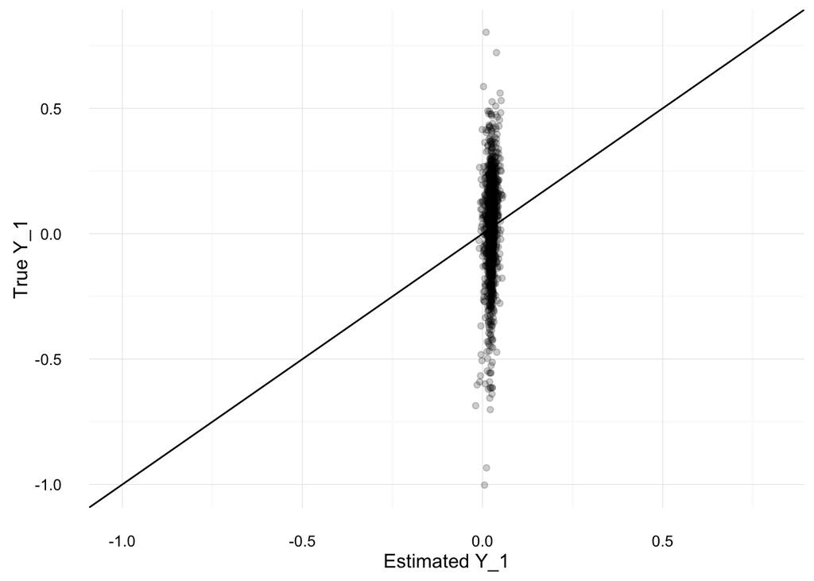

```r
yhat.boost <- predict(boost.hw, newdata = to_fit_y1[test,], n.trees =tuning.boost.hw$bestTune[,1])
hw.test <- to_fit_y1[-train, "Estimate"]


to_plot <- data.frame(estimated_y1 = yhat.boost,
                      true_y1 = to_fit_y1[test, "Estimate"])
ggplot(to_plot, aes(x = estimated_y1, y = true_y1)) +
  geom_point(alpha = 0.2) +
  xlim(range(to_plot)) + ylim(range(to_plot)) +
  theme_minimal() +
  geom_abline(intercept = 0, slope = 1) +
  xlab("Estimated Y_1") + ylab("True Y_1")
```

The mean squared error for this model was 2.694766910^{-5}.

Fit a xgboost model.

```r
df_train <- to_fit_y1[train,]

df_test <- to_fit_y1[-train,]

data <- as.matrix(df_train[,-17])
label=df_train[,17]
```

Tuning

```r
xgb.grid <- expand.grid(nrounds = 10,
                        eta = 0.1,  ### change c(0.01,0.05,0.1) to 0.1
                        max_depth = c(2,4,6,8,10,14),
                        gamma = 1,
                        colsample_bytree = 0.5,
                        min_child_weight=1
                        )
set.seed(45)
xgb_tune <-train(Estimate~.,
                 data=df_train,
                 method="xgbTree",
                 trControl=fitControl,
                 tuneGrid=xgb.grid,
                 verbose=T,
                 nthread =3)
xgb_tune
```

```
## eXtreme Gradient Boosting
##
## 1490 samples
##   25 predictor
##
## No pre-processing
## Resampling: Cross-Validated (10 fold)
## Summary of sample sizes: 1341, 1342, 1341, 1342, 1340, 1341, ...
## Resampling results across tuning parameters:
##
##   max_depth  RMSE       Rsquared
##    2         0.2588514  0.004488482
##    4         0.2595659  0.014035829
##    6         0.2593342  0.020224610
##    8         0.2588536  0.040429132
##   10         0.2593154  0.013658887
##   14         0.2588048  0.023166469
##
## Tuning parameter 'nrounds' was held constant at a value of 10
##
## Tuning parameter 'colsample_bytree' was held constant at a value of
##  0.5
## Tuning parameter 'min_child_weight' was held constant at a value of 1
## RMSE was used to select the optimal model using  the smallest value.
## The final values used for the model were nrounds = 10, max_depth = 14,
##  eta = 0.1, gamma = 1, colsample_bytree = 0.5 and min_child_weight = 1.
```